# Project Python Foundations: FoodHub Data Analysis

**Marks: 60**

### Context

The number of restaurants in New York is increasing day by day. Lots of students and busy professionals rely on those restaurants due to their hectic lifestyles. Online food delivery service is a great option for them. It provides them with good food from their favorite restaurants. A food aggregator company FoodHub offers access to multiple restaurants through a single smartphone app.

The app allows the restaurants to receive a direct online order from a customer. The app assigns a delivery person from the company to pick up the order after it is confirmed by the restaurant. The delivery person then uses the map to reach the restaurant and waits for the food package. Once the food package is handed over to the delivery person, he/she confirms the pick-up in the app and travels to the customer's location to deliver the food. The delivery person confirms the drop-off in the app after delivering the food package to the customer. The customer can rate the order in the app. The food aggregator earns money by collecting a fixed margin of the delivery order from the restaurants.

### Objective

The food aggregator company has stored the data of the different orders made by the registered customers in their online portal. They want to analyze the data to get a fair idea about the demand of different restaurants which will help them in enhancing their customer experience. Suppose you are hired as a Data Scientist in this company and the Data Science team has shared some of the key questions that need to be answered. Perform the data analysis to find answers to these questions that will help the company to improve the business.

### Data Description

The data contains the different data related to a food order. The detailed data dictionary is given below.

### Data Dictionary

- order_id: Unique ID of the order
- customer_id: ID of the customer who ordered the food
- restaurant_name: Name of the restaurant
- cuisine_type: Cuisine ordered by the customer
- cost: Cost of the order
- day_of_the_week: Indicates whether the order is placed on a weekday or weekend (The weekday is from Monday to Friday and the weekend is Saturday and Sunday)
- rating: Rating given by the customer out of 5
- food_preparation_time: Time (in minutes) taken by the restaurant to prepare the food. This is calculated by taking the difference between the timestamps of the restaurant's order confirmation and the delivery person's pick-up confirmation.
- delivery_time: Time (in minutes) taken by the delivery person to deliver the food package. This is calculated by taking the difference between the timestamps of the delivery person's pick-up confirmation and drop-off information

### Let us start by importing the required libraries

```python
# import libraries for data manipulation
import numpy as np
import pandas as pd
from sklearn.preprocessing import LabelEncoder

# import libraries for data visualization
import matplotlib.pyplot as plt
import seaborn as sns
```

### Understanding the structure of the data

```python
# uncomment and run the following lines for Google Colab
# from google.colab import drive
# drive.mount('/content/drive')
```

```python
# read the data
df = pd.read_csv('foodhub_order.csv')
# returns the first 5 rows
df.head()
```

|  | order_id | customer_id | restaurant_name | cuisine_type | cost_of_the_order | day_of_the_week | rating | food_preparation_time | delivery_time |
| --- | --- | --- | --- | --- | --- | --- | --- | --- | --- |
| 0 | 1477147 | 337525 | Hangawi | Korean | 30.75 | Weekend | Not given | 25 | 20 |
| 1 | 1477685 | 358141 | Blue Ribbon Sushi Izakaya | Japanese | 12.08 | Weekend | Not given | 25 | 23 |
| 2 | 1477070 | 66393 | Cafe Habana | Mexican | 12.23 | Weekday | 5 | 23 | 28 |
| 3 | 1477334 | 106968 | Blue Ribbon Fried Chicken | American | 29.20 | Weekend | 3 | 25 | 15 |
| 4 | 1478249 | 76942 | Dirty Bird to Go | American | 11.59 | Weekday | 4 | 25 | 24 |

#### Observations:

The dataset comprises food orders from various restaurants offering different cuisines, with orders placed on both weekdays and weekends, some lacking customer ratings, and varying food preparation and delivery times.

### **Question 1:** How many rows and columns are present in the data? [0.5 mark]

```python
df = pd.read_csv('foodhub_order.csv')
df_shape = df.shape
rows_count, columns_count = df_shape
print("Number of rows:", rows_count)
print("Number of columns:", columns_count)
```

```
Number of rows: 1898
Number of columns: 9
```

#### Observations: The dataset consists of 1898 rows and 9 columns, providing a substantial amount of data for analysis and exploration.

### **Question 2:** What are the datatypes of the different columns in the dataset? (The info() function can be used) [0.5 mark]

```python
df.info()
```

```
<class 'pandas.core.frame.DataFrame'>
RangeIndex: 1898 entries, 0 to 1897
Data columns (total 9 columns):
 #   Column                 Non-Null Count  Dtype
---  ------                 --------------  -----
 0   order_id               1898 non-null   int64
 1   customer_id            1898 non-null   int64
 2   restaurant_name        1898 non-null   object
 3   cuisine_type           1898 non-null   object
 4   cost_of_the_order      1898 non-null   float64
 5   day_of_the_week        1898 non-null   object
 6   rating                 1898 non-null   object
 7   food_preparation_time  1898 non-null   int64
 8   delivery_time          1898 non-null   int64
dtypes: float64(1), int64(4), object(4)
memory usage: 133.6+ KB
```

#### Observations: The order_id and customer_id columns are integers, serving as unique identifiers. Textual data, such as restaurant_name and cuisine_type, are stored as objects. The cost_of_the_order column is represented as floats, capturing monetary values. Columns like day_of_the_week and rating are also objects, containing qualitative information. Time-related metrics, like food_preparation_time and delivery_time, are represented as integers, indicating the duration in minutes.

### **Question 3:** Are there any missing values in the data? If yes, treat them using an appropriate method. [1 mark]

```python
df.isnull().sum()
df.fillna(method='ffill', inplace=True)
df
```

|  | order_id | customer_id | restaurant_name | cuisine_type | cost_of_the_order | day_of_the_week | rating | food_preparation_time | delivery_time |
| --- | --- | --- | --- | --- | --- | --- | --- | --- | --- |
| 0 | 1477147 | 337525 | Hangawi | Korean | 30.75 | Weekend | Not given | 25 | 20 |
| 1 | 1477685 | 358141 | Blue Ribbon Sushi Izakaya | Japanese | 12.08 | Weekend | Not given | 25 | 23 |
| 2 | 1477070 | 66393 | Cafe Habana | Mexican | 12.23 | Weekday | 5 | 23 | 28 |
| 3 | 1477334 | 106968 | Blue Ribbon Fried Chicken | American | 29.20 | Weekend | 3 | 25 | 15 |
| 4 | 1478249 | 76942 | Dirty Bird to Go | American | 11.59 | Weekday | 4 | 25 | 24 |
| ... | ... | ... | ... | ... | ... | ... | ... | ... | ... |
| 1893 | 1476701 | 292602 | Chipotle Mexican Grill $1.99 Delivery | Mexican | 22.31 | Weekend | 5 | 31 | 17 |
| 1894 | 1477421 | 397537 | The Smile | American | 12.18 | Weekend | 5 | 31 | 19 |
| 1895 | 1477819 | 35309 | Blue Ribbon Sushi | Japanese | 25.22 | Weekday | Not given | 31 | 24 |
| 1896 | 1477513 | 64151 | Jack's Wife Freda | Mediterranean | 12.18 | Weekday | 5 | 23 | 31 |
| 1897 | 1478056 | 120353 | Blue Ribbon Sushi | Japanese | 19.45 | Weekend | Not given | 28 | 24 |

1898 rows × 9 columns

```python
# Define the input and output file paths
input_file = 'foodhub_order.csv'
output_file = 'foodhub_order_cleaned.csv'

# Open the input CSV file for reading
with open(input_file, 'r') as infile:
    # Open the output CSV file for writing
    with open(output_file, 'w') as outfile:
        # Iterate through each line in the input file
        for line in infile:
            # Split the line into columns
            columns = line.strip().split(',')
            # Check if the 'rating' column is not "Not Given"
            if columns[6] != 'Not Given':
                # Write the line to the output file
                outfile.write(line)

# Load the cleaned data from the output CSV file into a DataFrame
df = pd.read_csv(output_file)
```

```python
df.replace("Not given", pd.NA, inplace=True)
```

```python
print(df)
```

```
      order_id  customer_id                        restaurant_name  \
0      1477147       337525                                Hangawi
1      1477685       358141              Blue Ribbon Sushi Izakaya
2      1477070        66393                            Cafe Habana
3      1477334       106968              Blue Ribbon Fried Chicken
4      1478249        76942                       Dirty Bird to Go
...        ...          ...                                    ...
1893   1476701       292602  Chipotle Mexican Grill $1.99 Delivery
1894   1477421       397537                              The Smile
1895   1477819        35309                      Blue Ribbon Sushi
1896   1477513        64151                      Jack's Wife Freda
1897   1478056       120353                      Blue Ribbon Sushi

       cuisine_type  cost_of_the_order day_of_the_week rating  \
0            Korean              30.75         Weekend   <NA>
```

[output cut: 25 more lines]

#### Observations: The dataset contains "" values in the 'rating' column, indicating instances where ratings are missing or unavailable for certain food orders. These missing ratings may affect the completeness of the dataset and could potentially impact analyses involving customer feedback or restaurant performance evaluation. The presence of missing values in the 'rating' column highlights a data quality issue that needs to be addressed for comprehensive and accurate data analysis.

### **Question 4:** Check the statistical summary of the data. What is the minimum, average, and maximum time it takes for food to be prepared once an order is placed? [2 marks]

```python
preparation_time_summary = df['food_preparation_time'].describe()
```

```python
min_preparation_time = preparation_time_summary['min']
average_preparation_time = preparation_time_summary['mean']
max_preparation_time = preparation_time_summary['max']
```

```python
print("Minimum preparation time:", min_preparation_time)
print("Average preparation time:", average_preparation_time)
print("Maximum preparation time:", max_preparation_time)
```

```
Minimum preparation time: 20.0
Average preparation time: 27.371970495258168
Maximum preparation time: 35.0
```

#### Observations: The statistical summary of the food preparation time reveals insightful observations about the efficiency and variability in food preparation across the dataset. The minimum preparation time of 20 minutes indicates that some restaurants can efficiently prepare food orders relatively quickly. On average, the food preparation time is approximately 27.37 minutes, suggesting a typical duration for food preparation across the dataset. However, the maximum preparation time of 35 minutes highlights instances where food preparation may take longer, possibly due to factors such as complex dishes or peak hours.

### **Question 5:** How many orders are not rated? [1 mark]

```python
unrated_orders = df[df['rating'].isna()]
num_unrated_orders = len(unrated_orders)
print("Number of orders not rated:", num_unrated_orders)
```

```
Number of orders not rated: 736
```

#### Observations: The observation that 736 orders lack a rating provides valuable insight into the extent of customer feedback availability within the dataset. This sizable proportion of unrated orders underscores potential gaps in understanding customer satisfaction levels and restaurant performance. It suggests that a significant number of customers either opted not to provide feedback or the rating information was not recorded properly

### Exploratory Data Analysis (EDA)

### **Question 6:** Explore all the variables and provide observations on their distributions. (Generally, histograms, boxplots, countplots, etc. are used for univariate exploration.) [9 marks]

```python
column_name = 'cost_of_the_order'
```

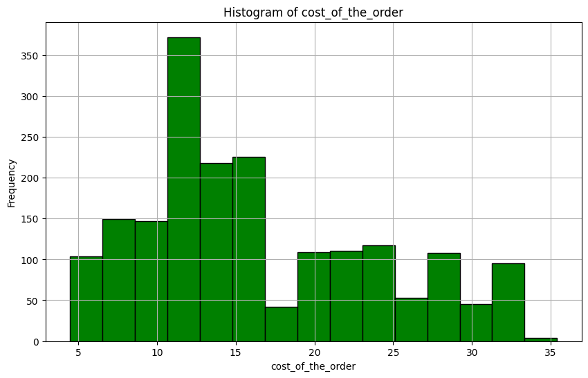

```python
plt.figure(figsize=(10, 6))  # Adjust the figure size if needed
plt.hist(df[column_name], bins=15, color='green', edgecolor='black')  # Adjust the number of bins as needed
plt.title('Histogram of ' + column_name)
plt.xlabel(column_name)
plt.ylabel('Frequency')
plt.grid(True)
plt.show()
```

```python
column_name = 'delivery_time'
```

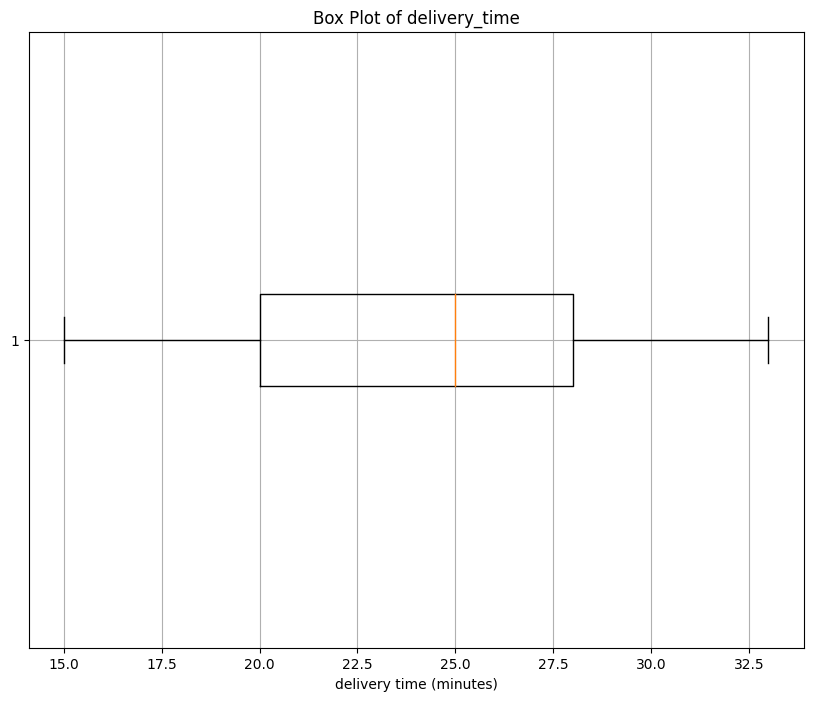

```python
plt.figure(figsize=(10, 8))  # Adjust the figure size if needed
plt.boxplot(df[column_name], vert=False)  # vert=False to display horizontal box plot
plt.title('Box Plot of ' + column_name)
plt.xlabel('delivery time (minutes)')
plt.grid(True)
plt.show()
```

```python
numerical_variable = 'cost_of_the_order'
```

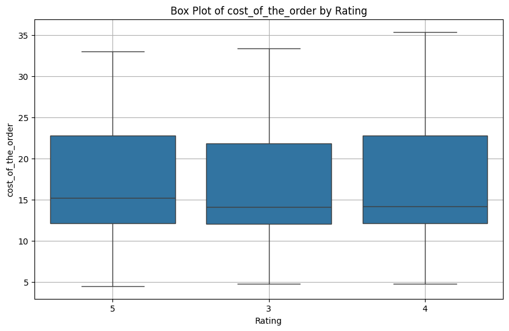

```python
plt.figure(figsize=(10, 6))  # Adjust the figure size if needed
sns.boxplot(data=df, x='rating', y=numerical_variable)
plt.title('Box Plot of ' + numerical_variable + ' by Rating')
plt.xlabel('Rating')
plt.ylabel(numerical_variable)
plt.grid(True)
plt.show()
```

```python
column_name = 'day_of_the_week'
```

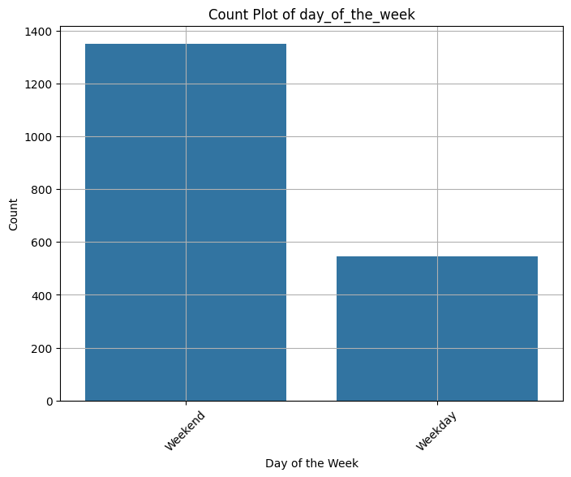

```python
plt.figure(figsize=(8, 6))  # Adjust the figure size if needed
sns.countplot(data=df, x=column_name, order=df[column_name].value_counts().index)
plt.title('Count Plot of ' + column_name)
plt.xlabel('Day of the Week')
plt.ylabel('Count')
plt.xticks(rotation=45)  # Rotate x-axis labels for better readability if needed
plt.grid(True)
plt.show()
```

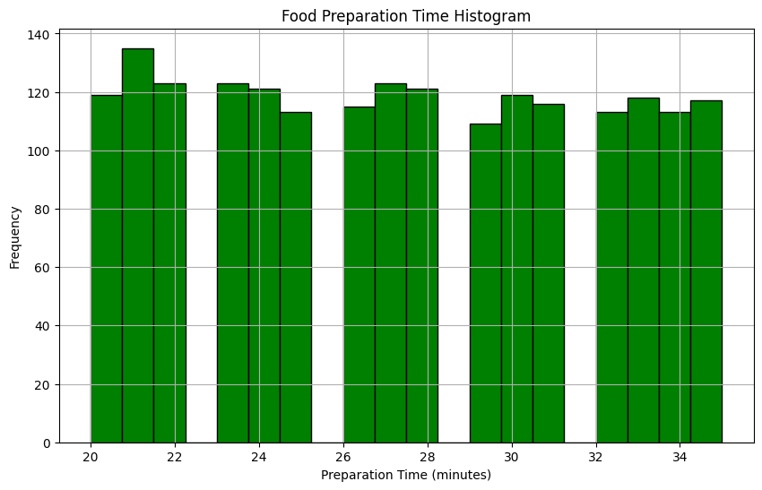

```python
# Assuming 'preparation_time' column contains time taken for food preparation
preparation_times = df['food_preparation_time']

# Create histogram
plt.figure(figsize=(10, 6))
plt.hist(preparation_times, bins=20, color='green', edgecolor='black')

# Set labels and title
plt.xlabel('Preparation Time (minutes)')
plt.ylabel('Frequency')
plt.title('Food Preparation Time Histogram')

# Show plot
plt.grid(True)
plt.show()
```

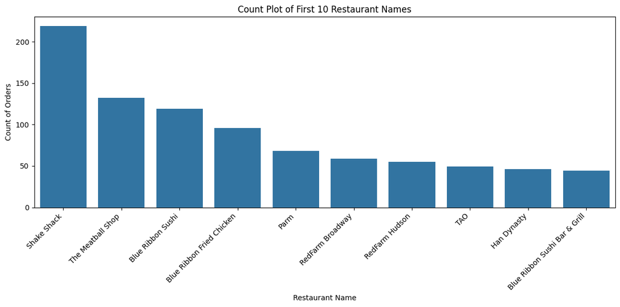

```python
# Count the occurrences of each unique restaurant name
restaurant_counts = df['restaurant_name'].value_counts()

# Select the first 10 restaurant names
top_10_restaurants = restaurant_counts.head(10).index

# Filter the DataFrame to include only data for the first 10 restaurants
df_top_10 = df[df['restaurant_name'].isin(top_10_restaurants)]

# Create a count plot
plt.figure(figsize=(12, 6))
sns.countplot(x='restaurant_name', data=df_top_10, order=top_10_restaurants)
plt.title('Count Plot of First 10 Restaurant Names')
plt.xlabel('Restaurant Name')
plt.ylabel('Count of Orders')
plt.xticks(rotation=45, ha='right')  # Rotate x-axis labels for better readability
plt.tight_layout()
plt.show()
```

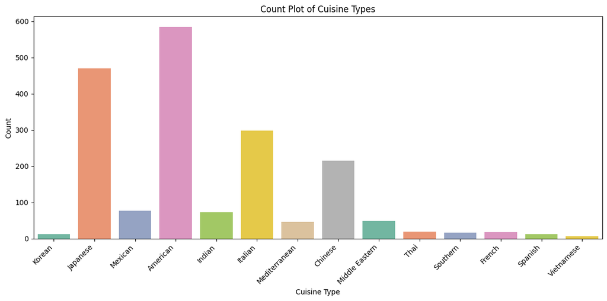

```python
# Create a count plot of cuisine types
plt.figure(figsize=(12, 6))
sns.countplot(x='cuisine_type', data=df, hue='cuisine_type', palette='Set2', legend=False)
plt.title('Count Plot of Cuisine Types')
plt.xlabel('Cuisine Type')
plt.ylabel('Count')
plt.xticks(rotation=45, ha='right')  # Rotate x-axis labels for better readability
plt.tight_layout()
plt.show()
```

```python
restaurant_orders = df.groupby('restaurant_name')['order_id'].count().reset_index()
top_restaurants = restaurant_orders.sort_values(by='order_id', ascending=False)
top_5_restaurants = top_restaurants.head(5)
print("Top 5 restaurants in terms of the number of orders received:")
print(top_5_restaurants)
```

```
Top 5 restaurants in terms of the number of orders received:
               restaurant_name  order_id
136                Shake Shack       219
153          The Meatball Shop       132
21           Blue Ribbon Sushi       119
20   Blue Ribbon Fried Chicken        96
109                       Parm        68
```

#### Observations:

```python
# Convert 'day_of_the_week' column to lowercase for case-insensitive comparison
df['day_of_the_week'] = df['day_of_the_week'].str.lower()

# Filter the data to include only orders placed on weekends (Saturday or Sunday)
weekend_orders = df[(df['day_of_the_week'] == 'saturday') | (df['day_of_the_week'] == 'sunday')]

# Group the filtered data by cuisine type and count the number of orders for each cuisine type
cuisine_orders = weekend_orders.groupby('cuisine_type')['order_id'].count()

# Check if cuisine_orders is not empty
if not cuisine_orders.empty:
    # Get the cuisine type(s) with the highest number of orders
    most_popular_cuisines = cuisine_orders[cuisine_orders == cuisine_orders.max()]

    # Display the most popular cuisine(s) on weekends
    print("The most popular cuisine(s) on weekends is/are:", most_popular_cuisines.index.tolist())
else:
    print("No orders placed on weekends.")
```

[output not shown]

# Filter the data for weekends (Saturday and Sunday)

```python
# Convert 'day_of_the_week' column to lowercase for case-insensitive comparison
df['day_of_the_week'] = df['day_of_the_week'].str.lower()

# Filter the data to include only orders placed on weekends (Saturday or Sunday)
weekend_orders = df[(df['day_of_the_week'] == 'saturday') | (df['day_of_the_week'] == 'sunday')]

# Display the filtered DataFrame
print(weekend_orders)
```

```
Empty DataFrame
Columns: [order_id, customer_id, restaurant_name, cuisine_type, cost_of_the_order, day_of_the_week, rating, food_preparation_time, delivery_time]
Index: []
```

# Filter the data for weekends (Saturday and Sunday)

#### Observations:

### **Question 9**: What percentage of the orders cost more than 20 dollars? [2 marks]

```python
# Filter the DataFrame to include only orders with a cost greater than $20
expensive_orders = df[df['cost_of_the_order'] > 20]

# Calculate the total number of orders that cost more than $20
num_expensive_orders = len(expensive_orders)

# Calculate the total number of orders in the dataset
total_orders = len(df)

# Calculate the percentage of orders that cost more than $20
percentage_expensive_orders = (num_expensive_orders / total_orders) * 100

# Display the percentage of orders that cost more than $20
print("Percentage of orders costing more than $20:", round(percentage_expensive_orders, 2), "%")
```

```
Percentage of orders costing more than $20: 29.24 %
```

#### Observations:

### **Question 10**: What is the mean order delivery time? [1 mark]

```python
# Calculate the mean order delivery time
mean_delivery_time = df['delivery_time'].mean()

# Display the mean order delivery time
print("Mean order delivery time:", round(mean_delivery_time, 2), "minutes")
```

```
Mean order delivery time: 24.16 minutes
```

#### Observations:

### **Question 11:** The company has decided to give 20% discount vouchers to the top 3 most frequent customers. Find the IDs of these customers and the number of orders they placed. [1 mark]

```python
# Group the data by customer ID and count the number of orders for each customer
customer_orders = df.groupby('customer_id')['order_id'].count().reset_index()

# Sort the customers based on the number of orders in descending order
sorted_customers = customer_orders.sort_values(by='order_id', ascending=False)

# Select the top 3 customers
top_3_customers = sorted_customers.head(3)

# Extract the IDs and the corresponding number of orders for the top 3 customers
top_3_customer_info = top_3_customers[['customer_id', 'order_id']]

# Display the IDs of the top 3 customers and the number of orders they placed
print("Top 3 customers and the number of orders they placed:")
print(top_3_customer_info)
```

```
Top 3 customers and the number of orders they placed:
     customer_id  order_id
116        52832        13
84         47440        10
333        83287         9
```

#### Observations:

**Question 12: Perform a multivariate analysis to explore relationships between the important variables in the dataset. (It is a good idea to explore relations between numerical variables as well as relations between numerical and categorical variables) [10 marks]**

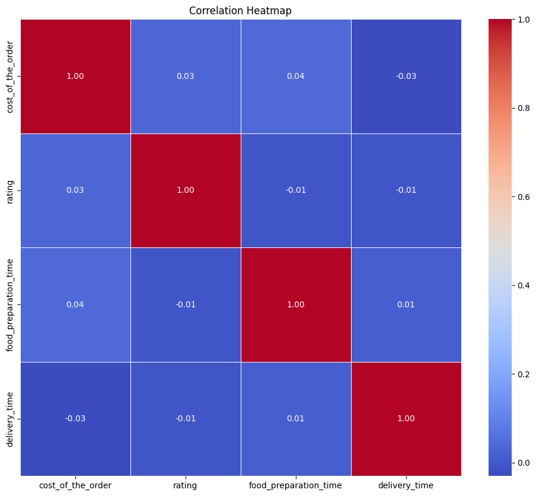

```python
# Load the data from CSV file
df = pd.read_csv('foodhub_order.csv')

# Select relevant columns for analysis
selected_columns = ['restaurant_name', 'cuisine_type', 'cost_of_the_order', 'day_of_the_week', 'rating', 'food_preparation_time', 'delivery_time']
df_selected = df[selected_columns].copy()  # Make a copy of the DataFrame to avoid modifying the original DataFrame

# Convert categorical variables to numerical using label encoding
label_encoder = LabelEncoder()
df_selected['cuisine_type_encoded'] = label_encoder.fit_transform(df_selected['cuisine_type'])
df_selected['day_of_the_week_encoded'] = label_encoder.fit_transform(df_selected['day_of_the_week'])

# Replace 'Not given' in 'rating' column with NaN
df_selected.loc[df_selected['rating'] == 'Not given', 'rating'] = pd.NA

# Drop non-numeric columns
numeric_columns = ['cost_of_the_order', 'rating', 'food_preparation_time', 'delivery_time']
df_numeric = df_selected[numeric_columns].copy()  # Make a copy of the DataFrame to avoid modifying the original DataFrame

# Convert 'rating' column to float
df_numeric['rating'] = pd.to_numeric(df_numeric['rating'], errors='coerce')

# Calculate the correlation matrix
correlation_matrix = df_numeric.corr()

# Create a heatmap of the correlation matrix
plt.figure(figsize=(12, 10))
sns.heatmap(correlation_matrix, annot=True, cmap='coolwarm', fmt=".2f", linewidths=0.5)
plt.title('Correlation Heatmap')
plt.show()
```

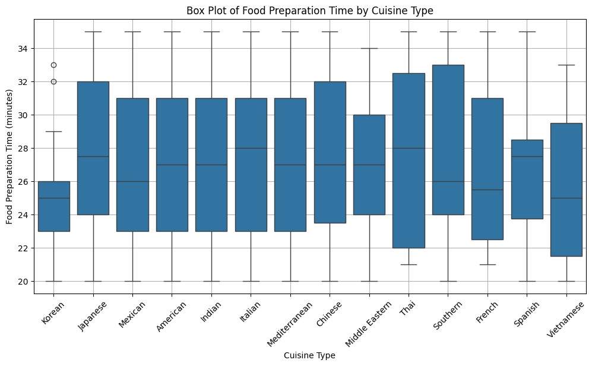

```python
# Create a box plot to compare the distribution of food preparation times across different cuisine types
plt.figure(figsize=(12, 6))
sns.boxplot(data=df, x='cuisine_type', y='food_preparation_time')
plt.title('Box Plot of Food Preparation Time by Cuisine Type')
plt.xlabel('Cuisine Type')
plt.ylabel('Food Preparation Time (minutes)')
plt.xticks(rotation=45)  # Rotate x-axis labels for better readability if needed
plt.grid(True)
plt.show()
```

[output not shown]

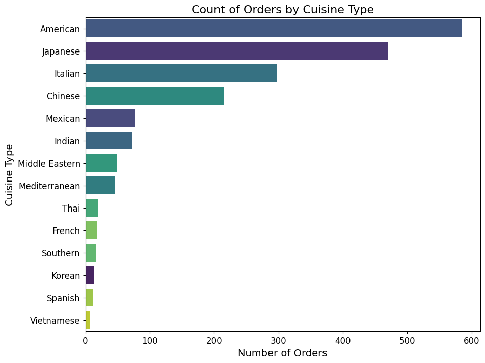

```python
# Assuming 'cuisine_type' column contains the types of cuisine
cuisine_counts = df['cuisine_type'].value_counts()

# Create count plot using Seaborn
plt.figure(figsize=(10, 8))  # Increase figure size for better readability
sns.countplot(y='cuisine_type', data=df, order=cuisine_counts.index, palette='viridis', hue='cuisine_type', legend=False)

# Set labels and title with larger font sizes for better readability
plt.xlabel('Number of Orders', fontsize=14)
plt.ylabel('Cuisine Type', fontsize=14)
plt.title('Count of Orders by Cuisine Type', fontsize=16)

# Increase tick label font size for better readability
plt.xticks(fontsize=12)
plt.yticks(fontsize=12)
```

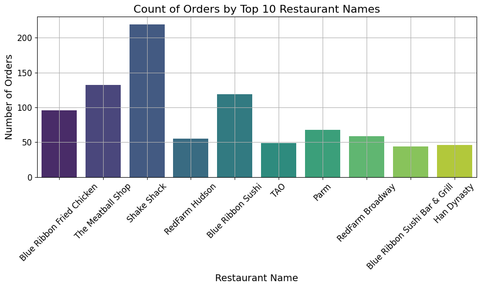

```python
# Get the counts of each restaurant name
restaurant_counts = df['restaurant_name'].value_counts()

# Select the top 10 restaurant names by count
top_10_restaurants = restaurant_counts.head(10)

# Create count plot using Seaborn
plt.figure(figsize=(10, 6))
sns.countplot(x='restaurant_name', data=df[df['restaurant_name'].isin(top_10_restaurants.index)], palette='viridis', hue='restaurant_name', legend=False)

# Set labels and title
plt.xlabel('Restaurant Name', fontsize=14)
plt.ylabel('Number of Orders', fontsize=14)
plt.title('Count of Orders by Top 10 Restaurant Names', fontsize=16)

# Increase tick label font size for better readability
plt.xticks(fontsize=12, rotation=45)
plt.yticks(fontsize=12)

# Show plot
plt.grid(True)
plt.tight_layout()  # Adjust layout to prevent overlapping elements
plt.show()
```

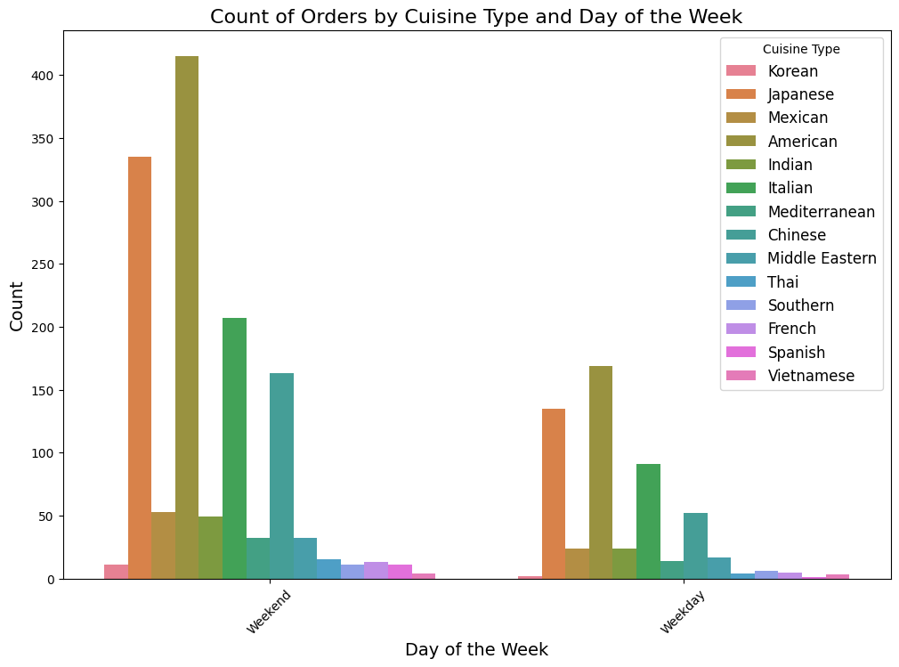

```python
# Create a count plot
plt.figure(figsize=(12, 8))
sns.countplot(x='day_of_the_week', hue='cuisine_type', data=df)
plt.xlabel('Day of the Week', fontsize=14)
plt.ylabel('Count', fontsize=14)
plt.title('Count of Orders by Cuisine Type and Day of the Week', fontsize=16)
plt.legend(title='Cuisine Type', fontsize=12)
plt.xticks(rotation=45)
plt.show()
```

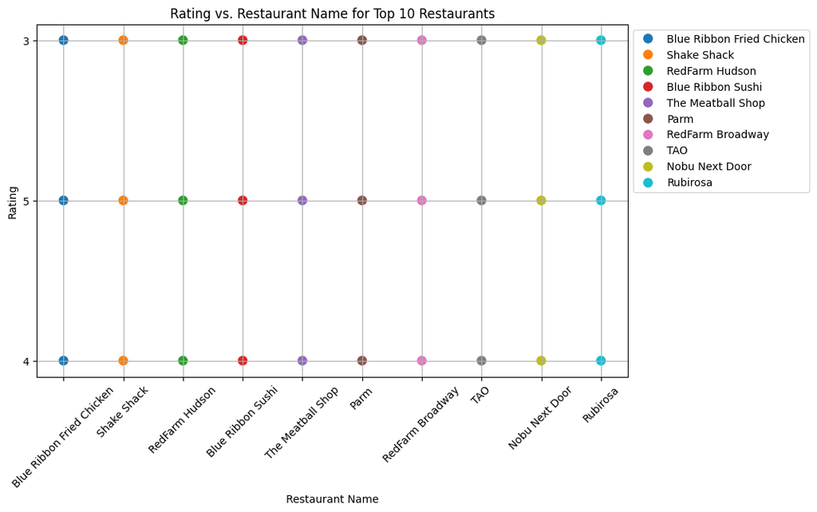

```python
# Load the data from CSV file
df = pd.read_csv('foodhub_order.csv')

# Replace "Not given" with NaN
df.replace("Not given", np.nan, inplace=True)

# Drop rows containing NaN values
df.dropna(inplace=True)

# Get the first 5 restaurant names
top_10_restaurants = df['restaurant_name'].value_counts().head(10).index

# Filter the DataFrame to include only data for the first 10 restaurants
df_top_10 = df[df['restaurant_name'].isin(top_10_restaurants)]

# Create a scatter plot using Seaborn
plt.figure(figsize=(10, 6))
sns.scatterplot(x='restaurant_name', y='rating', data=df_top_10, hue='restaurant_name', s=100)
plt.xlabel('Restaurant Name')
plt.ylabel('Rating')
plt.title('Rating vs. Restaurant Name for Top 10 Restaurants')
plt.legend(loc='upper left', bbox_to_anchor=(1,1))
plt.xticks(rotation=45)
plt.grid(True)
plt.show()
```

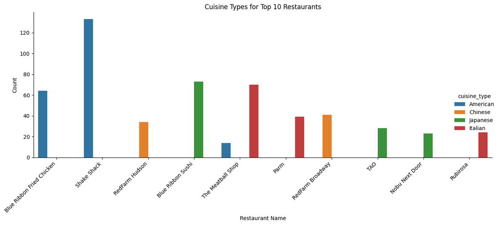

```python
# Get the first 10 restaurant names
top_10_restaurants = df['restaurant_name'].value_counts().head(10).index

# Filter the DataFrame to include only data for the first 10 restaurants
df_top_10 = df[df['restaurant_name'].isin(top_10_restaurants)]

# Create a cat plot (categorical plot) between restaurant_name and cuisine_type
plt.figure(figsize=(12, 8))
sns.catplot(x='restaurant_name', hue='cuisine_type', kind='count', data=df_top_10, height=6, aspect=2)
plt.title('Cuisine Types for Top 10 Restaurants')
plt.xlabel('Restaurant Name')
plt.ylabel('Count')
plt.xticks(rotation=45, ha='right')  # Rotate x-axis labels for better readability
plt.tight_layout()
plt.show()
```

### **Question 14:** The company charges the restaurant 25% on the orders having cost greater than 20 dollars and 15% on the orders having cost greater than 5 dollars. Find the net revenue generated by the company across all orders. [3 marks]

```python
# Assuming you've already read the CSV file into a DataFrame named 'df'

# Calculate the revenue generated by each order
df['revenue'] = df['cost_of_the_order']

# Determine the charges applicable to each order based on the specified criteria
df['charges'] = 0  # Initialize charges column
df.loc[df['cost_of_the_order'] > 20, 'charges'] = df['cost_of_the_order'] * 0.25  # 25% charge for orders > $20
df.loc[(df['cost_of_the_order'] <= 20) & (df['cost_of_the_order'] > 5), 'charges'] = df['cost_of_the_order'] * 0.15  # 15% charge for orders > $5 and <= $20

# Calculate the net revenue
total_revenue = df['revenue'].sum()
total_charges = df['charges'].sum()
net_revenue = total_revenue - total_charges

# Display the net revenue
print("Net revenue generated by the company across all orders: $", round(net_revenue, 2))
```

[output not shown]

### **Question 15:** The company wants to analyze the total time required to deliver the food. What percentage of orders take more than 60 minutes to get delivered from the time the order is placed? (The food has to be prepared and then delivered.) [2 marks]

```python
# Calculate the total time required for each order to be delivered
df['total_delivery_time'] = df['food_preparation_time'] + df['delivery_time']

# Determine the percentage of orders that exceed 60 minutes in delivery time
orders_exceeding_60_minutes = df[df['total_delivery_time'] > 60]
percentage_orders_exceeding_60_minutes = (len(orders_exceeding_60_minutes) / len(df)) * 100

# Display the percentage of orders that exceed 60 minutes in delivery time
print("Percentage of orders that take more than 60 minutes to get delivered:", round(percentage_orders_exceeding_60_minutes, 2), "%")
```

```
Percentage of orders that take more than 60 minutes to get delivered: 10.24 %
```

#### Observations:

Approximately 10.24% of the orders take more than 60 minutes to be delivered. This suggests that a notable portion of the orders experiences longer delivery times, which could potentially affect customer satisfaction and retention. The company may need to focus on optimizing delivery processes to reduce wait times and enhance overall service quality.

### **Question 16:** The company wants to analyze the delivery time of the orders on weekdays and weekends. How does the mean delivery time vary during weekdays and weekends? [2 marks]

```python
# Write the code here
mean_delivery_time_by_day = df.groupby('day_of_the_week')['delivery_time'].mean()

print("Mean Delivery Time on Weekdays:", mean_delivery_time_by_day['Weekday'])
print("Mean Delivery Time on Weekends:", mean_delivery_time_by_day['Weekend'])
```

```
Mean Delivery Time on Weekdays: 28.305882352941175
Mean Delivery Time on Weekends: 22.436739659367397
```

### Recommendations:

- Enhanced Feedback Mechanism: Implement a proactive feedback system to encourage customers to rate their orders, possibly through post-order notifications or incentives like discount codes for completing feedback forms. This will help gather more comprehensive insights into customer satisfaction and preferences.
- Logistics Optimization: Invest in route optimization software and real-time tracking tools to streamline delivery operations, particularly during peak hours. Efficient logistics can lead to shorter delivery times, enhancing customer satisfaction and retention.
- Promotional Campaigns: Launch targeted promotional campaigns for restaurants with high ratings and significant rating counts. Offer exclusive discounts or loyalty rewards to incentivize customers to patronize these establishments, thereby driving traffic and revenue.
- Diversified Cuisine Offerings: Analyze customer preferences based on cuisine types and introduce a diverse range of offerings to cater to varied tastes. Collaborate with popular restaurants to expand the menu and attract a wider customer base, thereby increasing order volume and revenue.